# IntelliJIDEAでSwing

> オブジェクト指向プログラミングおよび演習1 第13回

> GUIオブジェクトの配置をコードで書くと面倒なので、GUIツール使いましょう

## 1.プロジェクトの作成

以下の構成のプロジェクトを作成します。

- プロジェクト名 : 「FormSample」

## 2.GUIフォームの追加

以下の画像を参考に、「src」ディレクトリ以下にGUIフォームを作成しましょう。

[figure not shown]

※もし、GUIフォームの新規作成がメニューにない場合、IntelliJ IDEAの環境設定より、プラグインの項目から「UIデザイナー」を探してインストールしましょう。

フォーム名は、`TextInputSample`とします。

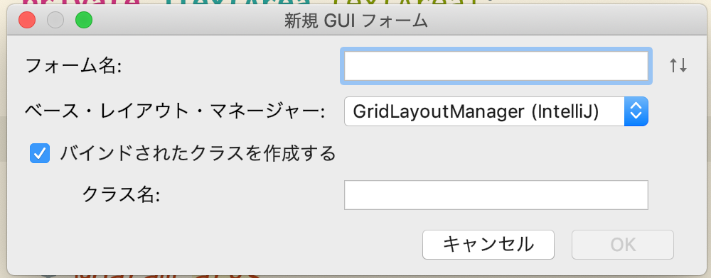

フォームを作成すると、以下の画面のように、デザイナ画面が起動します。

[figure not shown]

今回は、以下の画面構成に従いGUIを作成します。 配置を行う際に、コンポーネントの親子関係を確認しながら設定を行う必要がありますので、画面赤枠で指定されている「コンポーネントツリー」をよく確認して作業を行ってください。 詳しい指示は、講義内で行います。

[figure not shown]